# BA assignment 1

#### the file contains Descriptive statistics solutions and Data wrangling results of a dataset of Transaction data of Online Retail company and its countries in multiple countries.

### Part A) Descriptive Statistics & Normal Distributions

1.What is the probability of obtaining a score greater than 700 on a GMAT test that has a mean of 494 and a standard deviation of 100? Assume GMAT scores are normally distributed ?

```r
1-pnorm(2.06)
```

```
## [1] 0.01969927
```

### or

```r
1-pnorm(700,mean=494,sd=100)
```

```
## [1] 0.01969927
```

So 1.97% of total would exceed score of 700.

2.Runzheimer International publishes business travel costs for various cities throughout the world. In particular, they publish per diem totals, which represent the average costs for the typical business traveler including three meals a day in business-class restaurants and single-rate lodging in business-class hotels and motels. If 86.65% of the per diem costs in Buenos Aires, Argentina, are less than $449 and if the standard deviation of per diem costs is $36, what is the average per diem cost in Buenos Aires? Assume that per diem costs are normally distributed.

*We will do this in two steps: + The Z-score for 86.65% is Calculated by q norm

```r
qnorm(0.8665)
```

```
## [1] 1.109998
```

if z is 1.11 value of mean = $449 - $36(1.11)= $409.04

3.Calculate the correlation (Pearson Correlation Coefficient) between the temperatures of the two cities without using any R commands i.e. calculate step by step. Kent=c(59, 68, 78, 60) Los_Angeles=c(90, 82, 78, 75)

```r
library(ISLR)
kent=c(59,68,78,60)
Los_Angeles=c(90,82,78,75)
cor(kent,Los_Angeles,method = 'pearson')
```

```
## [1] -0.3566049
```

## Part B) Data Wrangling

```r
library('dplyr')
invoice <- read.csv(file = "Online_Retail.csv")
colnames(invoice)
```

```
## [1] "InvoiceNo"   "StockCode"   "Description" "Quantity"    "InvoiceDate"
## [6] "UnitPrice"   "CustomerID"  "Country"
```

4.The breakdown of the number of transactions by countries i.e. how many transactions are in the dataset for each country (consider all records including cancelled transactions). Showing total number and also in percentage. only countries accounting for more than 1% of the total transactions.

```r
invoice %>% group_by(Country) %>%
  summarise(Total_Transactions=n(), Percentage_Transactions = (n()/nrow(invoice))*100) %>%
  filter(Percentage_Transactions > 1)
```

```
## # A tibble: 3 x 3
##   Country        Total_Transactions Percentage_Transactions
##   <fct>                       <int>                   <dbl>
## 1 France                        967                    1.48
## 2 Germany                       982                    1.50
## 3 United Kingdom              61186                   93.4
```

5. a new variable ‘TransactionValue’ that is the product of the exising ‘Quantity’ and ‘UnitPrice’ variables. Add this variable to the dataframe.

```r
invoice$TransactionValue = invoice$Quantity * invoice$UnitPrice
head(invoice)
```

```
##   InvoiceNo StockCode                         Description Quantity
## 1    536365    85123A  WHITE HANGING HEART T-LIGHT HOLDER        6
## 2    536365     71053                 WHITE METAL LANTERN        6
## 3    536365    84406B      CREAM CUPID HEARTS COAT HANGER        8
## 4    536365    84029G KNITTED UNION FLAG HOT WATER BOTTLE        6
## 5    536365    84029E      RED WOOLLY HOTTIE WHITE HEART.        6
## 6    536365     22752        SET 7 BABUSHKA NESTING BOXES        2
##      InvoiceDate UnitPrice CustomerID        Country TransactionValue
## 1 12/1/2010 8:26      2.55      17850 United Kingdom            15.30
## 2 12/1/2010 8:26      3.39      17850 United Kingdom            20.34
## 3 12/1/2010 8:26      2.75      17850 United Kingdom            22.00
## 4 12/1/2010 8:26      3.39      17850 United Kingdom            20.34
## 5 12/1/2010 8:26      3.39      17850 United Kingdom            20.34
## 6 12/1/2010 8:26      7.65      17850 United Kingdom            15.30
```

6.the breakdown of transaction values by countries i.e. how much money in total has been spent each country. Show this in total sum of transaction values. Show only countries with total transaction exceeding 130,000 British Pound

```r
invoice %>% group_by(Country) %>% summarise(TransValue=sum(TransactionValue)) %>% filter(TransValue>130000)
```

```
## # A tibble: 1 x 2
##   Country        TransValue
##   <fct>               <dbl>
## 1 United Kingdom    965043.
```

7 .for the set of next fpur questions we , first covert and split the invoice date field into day of the week , month and hour

```r
Temp=strptime(invoice$InvoiceDate,format='%m/%d/%Y %H:%M',tz='GMT')
invoice$New_Invoice_Date <- as.Date(Temp)
invoice$Invoice_Day_Week= weekdays(invoice$New_Invoice_Date)
invoice$New_Invoice_Hour = as.numeric(format(Temp, "%H"))
invoice$New_Invoice_Month = as.numeric(format(Temp, "%m"))
```

7.a)percentage of transactions (by numbers) by days of the week

```r
invoice %>% group_by(Invoice_Day_Week) %>% summarise(trans_perday = n()/nrow(invoice) * 100)
```

```
## # A tibble: 6 x 2
##   Invoice_Day_Week trans_perday
##   <chr>                   <dbl>
## 1 Friday                  17.4
## 2 Monday                  19.0
## 3 Sunday                   9.86
## 4 Thursday                18.5
## 5 Tuesday                 16.4
## 6 Wednesday               18.9
```

```r
Total_TransactionVal = sum(invoice$TransactionValue)
Total_TransactionVal
```

```
## [1] 1122291
```

7.c)percentage of transactions (by transaction volume) by month of the year

```r
invoice %>% group_by(New_Invoice_Month) %>% summarise(trans_perday = sum(TransactionValue)/Total_TransactionVal * 100)
```

```
## # A tibble: 2 x 2
##   New_Invoice_Month trans_perday
##               <dbl>        <dbl>
## 1                 1         33.3
## 2                12         66.7
```

```r
Aus_Tran = invoice %>% filter(Country == 'Australia') %>% group_by(New_Invoice_Date) %>% summarise(max_tran_amt = sum(TransactionValue))
Aus_Tran %>% filter(max_tran_amt == max(max_tran_amt))
```

```
## # A tibble: 1 x 2
##   New_Invoice_Date max_tran_amt
##   <date>                  <dbl>
## 1 2011-01-06              7154.
```

7.e)the hour of the day to start this so that the distribution is at minimum for the customers.The responsible IT team is available from 7:00 to 20:00 every day

```r
invoice %>% group_by(New_Invoice_Hour) %>% summarise(tran_count = n())
```

```
## # A tibble: 14 x 2
##    New_Invoice_Hour tran_count
##               <dbl>      <int>
##  1                7         14
##  2                8        300
##  3                9       4939
##  4               10       4970
##  5               11       7658
##  6               12       7575
##  7               13       8193
##  8               14      11264
##  9               15       9417
## 10               16       5326
## 11               17       4163
## 12               18       1235
## 13               19        380
## 14               20         65
```

# Result :7 to 8 would be the best hours

8.the histogram of transaction values from Germany. Use the hist() function to plot

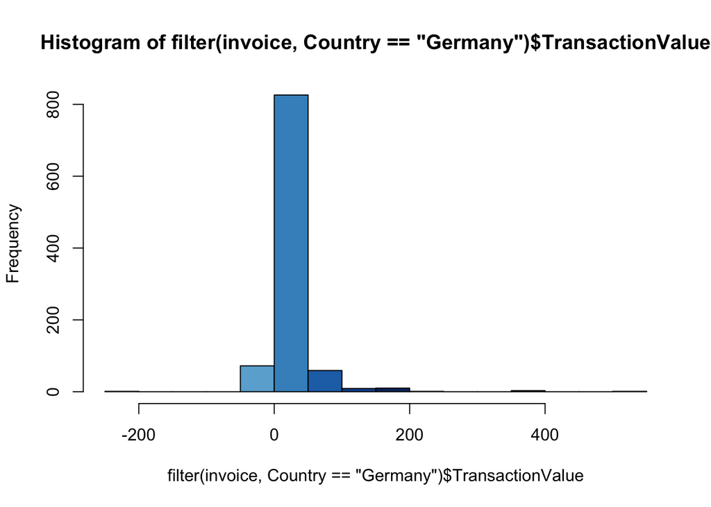

```r
hist(filter(invoice,Country=='Germany')$TransactionValue,col = blues9)
```

9.the highest number of transactions and the most valuable customer (i.e. highest total sum of transactions) +customer with highest transaction

```r
customer_grp <- invoice %>% group_by(CustomerID) %>% summarise(customer_transaction = n())
filter(customer_grp,customer_transaction==max(customer_grp$customer_transaction))
```

```
## # A tibble: 1 x 2
##   CustomerID customer_transaction
##        <int>                <int>
## 1         NA                25281
```

+customer with highest value

```r
highestval_cust <- invoice %>% group_by(CustomerID) %>% summarise(highestvalue = sum(TransactionValue))
highestval_cust = highestval_cust[complete.cases(highestval_cust),]
filter(highestval_cust,highestvalue==max(highestval_cust$highestvalue))
```

```
## # A tibble: 1 x 2
##   CustomerID highestvalue
##        <int>        <dbl>
## 1      18102       27835.
```

10.the percentage of missing values for each variable in the dataset

```r
colMeans(is.na(invoice))
```

```
##         InvoiceNo         StockCode       Description          Quantity
##         0.0000000         0.0000000         0.0000000         0.0000000
##       InvoiceDate         UnitPrice        CustomerID           Country
##         0.0000000         0.0000000         0.3859754         0.0000000
##  TransactionValue  New_Invoice_Date  Invoice_Day_Week  New_Invoice_Hour
##         0.0000000         0.0000000         0.0000000         0.0000000
## New_Invoice_Month
##         0.0000000
```

11.the number of transactions with missing CustomerID records by countries

```r
invoice %>% group_by(Country) %>% summarise(missing_customerid = sum(is.na(CustomerID)))
```

```
## # A tibble: 24 x 2
##    Country         missing_customerid
##    <fct>                        <int>
##  1 Australia                        0
##  2 Austria                          0
##  3 Bahrain                          2
##  4 Belgium                          0
##  5 Channel Islands                  0
##  6 Cyprus                           0
##  7 Denmark                          0
##  8 EIRE                            42
##  9 Finland                          0
## 10 France                           0
## # ... with 14 more rows
```

12.how often the costumers comeback to the website for their next shopping

```r
dt <- invoice %>% group_by(New_Invoice_Date) %>% summarise(cnt=n())
avg_days = max(diff(dt$New_Invoice_Date,1))
print(avg_days)
```

```
## Time difference of 12 days
```

13.return rate for the French customers.Considering the cancelled transactions as those where the ‘Quantity’ variable has a negative value.

```r
frech_cust <- filter(invoice,Country == 'France')

cancell_tran <- filter(frech_cust,Quantity < 0)
return_rate = nrow(cancell_tran) / nrow(frech_cust)
print(return_rate)
```

```
## [1] 0.01034126
```

14.the product that has generated the highest revenue for the retailer

```r
prod = invoice %>% group_by(Description) %>% summarise(highestprodval = sum(TransactionValue))
filter(prod, highestprodval == max(highestprodval))
```

```
## # A tibble: 1 x 2
##   Description              highestprodval
##   <fct>                             <dbl>
## 1 REGENCY CAKESTAND 3 TIER         35120.
```

15.unique customers are represented in the dataset? You can use unique() and length() functions

```r
a = invoice
a[complete.cases(a),] %>% summarise(uniquer_customer = n())
```

```
##   uniquer_customer
## 1            40218
```